# Pertemuan 5

2025-09-25

## Library

```r
library(ggplot2)
library(tsibble)
library(tseries)
library(MASS)
```

## Data

```r
cf = read.csv("C:/Users/ASUS/Downloads/coffee_prices.csv")
print(head(cf))
```

```
##   X Date..Monthly. Coffee.Arabica.....kg.
## 1 1       1/1/1960                 0.9409
## 2 2       2/1/1960                 0.9469
## 3 3       3/1/1960                 0.9281
## 4 4       4/1/1960                 0.9303
## 5 5       5/1/1960                 0.9200
## 6 6       6/1/1960                 0.9123
```

```r
# Potong data untuk baris 401-500
cf_subset = cf[401:500, ]
print(head(cf_subset))
```

```
##       X Date..Monthly. Coffee.Arabica.....kg.
## 401 401       5/1/1993                 1.3708
## 402 402       6/1/1993                 1.3779
## 403 403       7/1/1993                 1.5831
## 404 404       8/1/1993                 1.6958
## 405 405       9/1/1993                 1.7807
## 406 406      10/1/1993                 1.6896
```

### Ubah data menjadi bulanan

```r
cf_subset$Date.Monthly = as.Date(cf_subset$Date..Monthly., format = "%m/%d/%Y")
cf_subset$MonthYear = format(cf_subset$Date.Monthly, "%m/%Y")
print(head(cf_subset))
```

```
##       X Date..Monthly. Coffee.Arabica.....kg. Date.Monthly MonthYear
## 401 401       5/1/1993                 1.3708   1993-05-01   05/1993
## 402 402       6/1/1993                 1.3779   1993-06-01   06/1993
## 403 403       7/1/1993                 1.5831   1993-07-01   07/1993
## 404 404       8/1/1993                 1.6958   1993-08-01   08/1993
## 405 405       9/1/1993                 1.7807   1993-09-01   09/1993
## 406 406      10/1/1993                 1.6896   1993-10-01   10/1993
```

### Ubah data jadi time series

```r
# Tentukan tahun & bulan awal dari data subset
tahun_awal = as.numeric(format(min(cf_subset$Date.Monthly), "%Y"))
bulan_awal = as.numeric(format(min(cf_subset$Date.Monthly), "%m"))

# Ubah coffee arabica menjadi harga
harga = cf_subset$Coffee.Arabica

# Buat time series
ts_koi = ts(harga, start = c(tahun_awal, bulan_awal), frequency = 12)
ts_koi
```

```
##         Jan    Feb    Mar    Apr    May    Jun    Jul    Aug    Sep    Oct
## 1993                             1.3708 1.3779 1.5831 1.6958 1.7807 1.6896
## 1994 1.7405 1.8503 1.9181 1.9967 2.6870 3.1621 4.8256 4.4189 4.8943 4.4500
## 1995 3.8056 3.7431 3.9558 3.8449 3.7701 3.4059 3.2112 3.3777 2.9643 2.8058
## 1996 2.4394 2.7357 2.6641 2.7227 2.8499 2.7659 2.7000 2.7827 2.6169 2.7381
## 1997 2.9291 3.7119 4.2924 4.5633 5.8923 4.8947 4.1978 4.2064 4.1859 3.6963
## 1998 3.9198 3.9282 3.4756 3.3146 3.0362 2.7542 2.5926 2.7163 2.4659 2.4189
## 1999 2.4903 2.3254 2.3234 2.2511 2.4487 2.3636 2.0911 2.0144 1.8587 2.0768
## 2000 2.4496 2.2805 2.2207 2.0858 2.0756 1.9057 1.9257 1.6958 1.6707 1.6901
## 2001 1.4546 1.4813 1.4661 1.4579 1.5260 1.4088 1.2946 1.3166
##         Nov    Dec
## 1993 1.7328 1.7921
## 1994 4.0325 3.7157
## 1995 2.7613 2.3422
## 1996 2.7353 2.5798
## 1997 3.5333 3.9119
## 1998 2.5655 2.5880
## 1999 2.4996 2.7439
## 2000 1.5772 1.4586
## 2001
```

## Plot

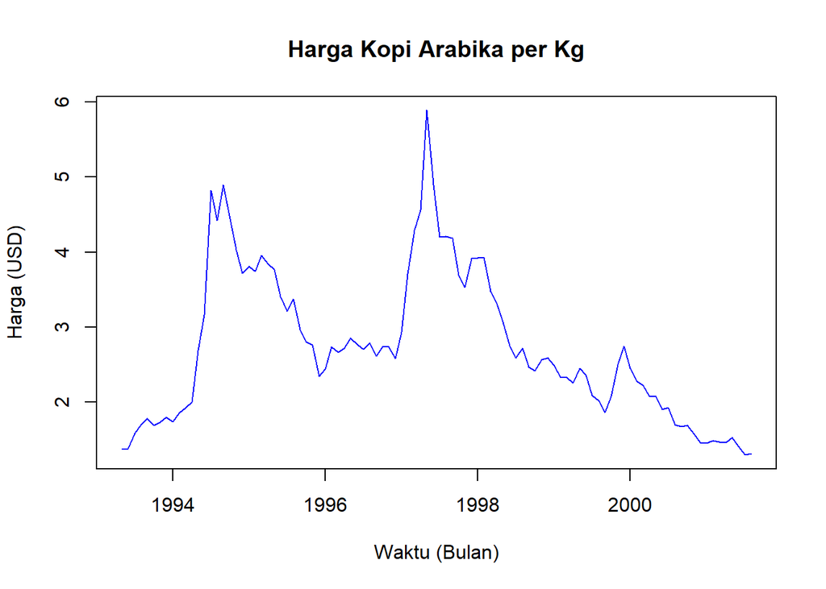

```r
plot(ts_koi, main = "Harga Kopi Arabika per Kg", ylab = "Harga (USD)", xlab = "Waktu (Bulan)", col = "blue")
```

## Cek Stasioneritas

```r
mean(ts_koi)
```

```
## [1] 2.727529
```

```r
var(ts_koi)
```

```
## [1] 0.9965086
```

### ACF

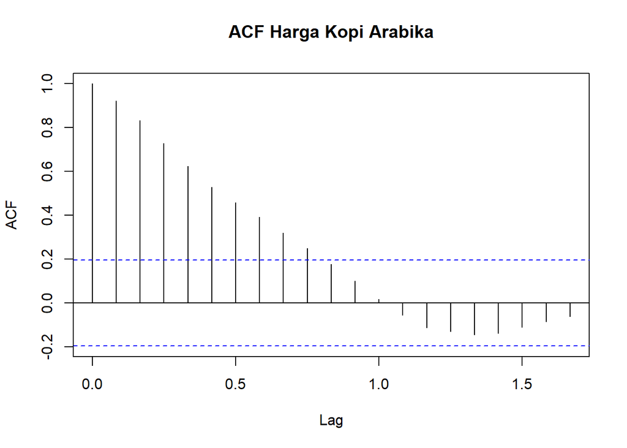

```r
acf(ts_koi, main = "ACF Harga Kopi Arabika")
```

Dari plot di atas menunjukkan bahwa data tidak stasioner karena nilai ACF menurun secara perlahan.

### Uji ADF

```r
adf.test(ts_koi)
```

```
##
##  Augmented Dickey-Fuller Test
##
## data:  ts_koi
## Dickey-Fuller = -2.7413, Lag order = 4, p-value = 0.2696
## alternative hypothesis: stationary
```

$H_0$ : Data tidak stasioner dalam rataan

$H_1$ : Data stasioner dalam rataan

Karena p-value > 0.05, maka gagal menolak H0 yang artinya terdapat ketidakstasioneran pada data.

### Plot Box-Cox

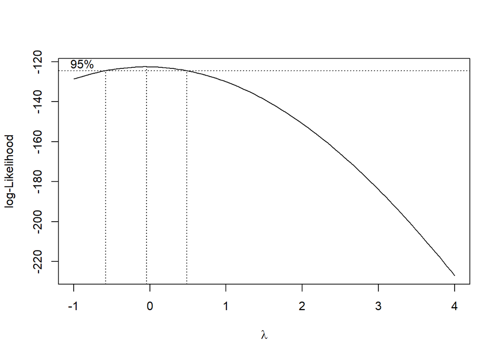

```r
index = seq(401:500)
b = boxcox(ts_koi~index, lambda = seq(-1,4,by=1))
```

```r
#Nilai Rounded Lambda
lambda = b$x[which.max(b$y)]
lambda
```

```
## [1] -0.04040404
```

```r
#SK
b$x[b$y > max(b$y) - 1/2 * qchisq(.95,1)]
```

```
##  [1] -0.54545455 -0.49494949 -0.44444444 -0.39393939 -0.34343434 -0.29292929
##  [7] -0.24242424 -0.19191919 -0.14141414 -0.09090909 -0.04040404  0.01010101
## [13]  0.06060606  0.11111111  0.16161616  0.21212121  0.26262626  0.31313131
## [19]  0.36363636  0.41414141  0.46464646
```

Plot di atas menunjukkan nilai *rounded value* ($\lambda$) optimum sebesar **-0.0404** dan pada selang kepercayaan 95% nilai memiliki batas bawah **-0.54** dan batas atas **0.46**. Selang tersebut tidak memuat nilai satu sehingga dapat dikatakan bahwa data tidak stasioner dalam ragam.

## Partisi Data

### Train Data

```r
train_size = floor(0.8 * length(ts_koi))
train_data = ts_koi[1:train_size]
print(train_data)
```

```
##  [1] 1.3708 1.3779 1.5831 1.6958 1.7807 1.6896 1.7328 1.7921 1.7405 1.8503
## [11] 1.9181 1.9967 2.6870 3.1621 4.8256 4.4189 4.8943 4.4500 4.0325 3.7157
## [21] 3.8056 3.7431 3.9558 3.8449 3.7701 3.4059 3.2112 3.3777 2.9643 2.8058
## [31] 2.7613 2.3422 2.4394 2.7357 2.6641 2.7227 2.8499 2.7659 2.7000 2.7827
## [41] 2.6169 2.7381 2.7353 2.5798 2.9291 3.7119 4.2924 4.5633 5.8923 4.8947
## [51] 4.1978 4.2064 4.1859 3.6963 3.5333 3.9119 3.9198 3.9282 3.4756 3.3146
## [61] 3.0362 2.7542 2.5926 2.7163 2.4659 2.4189 2.5655 2.5880 2.4903 2.3254
## [71] 2.3234 2.2511 2.4487 2.3636 2.0911 2.0144 1.8587 2.0768 2.4996 2.7439
```

```r
mean(train_data)
```

```
## [1] 2.978887
```

```r
var(train_data)
```

```
## [1] 0.9002073
```

### Plot Time Series Train Data

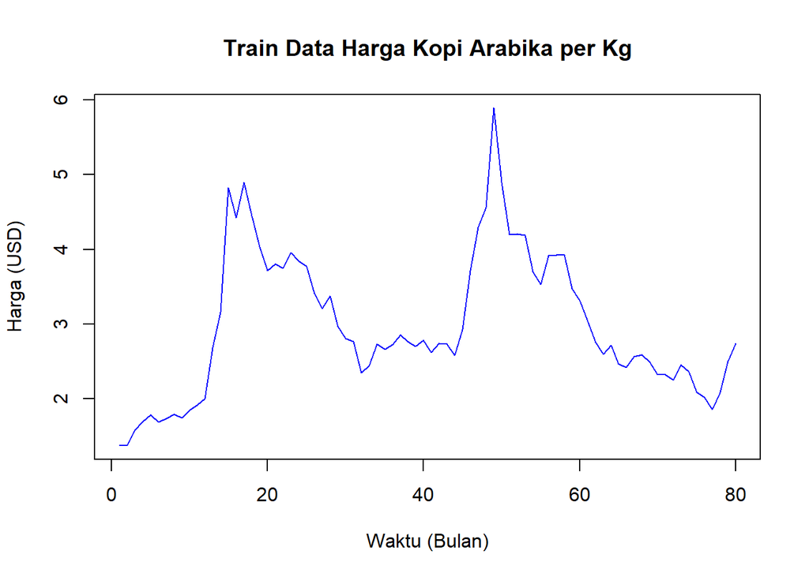

```r
plot.ts(train_data, main = "Train Data Harga Kopi Arabika per Kg", ylab = "Harga (USD)", xlab = "Waktu (Bulan)", col = "blue")
```

### ACF Train Data

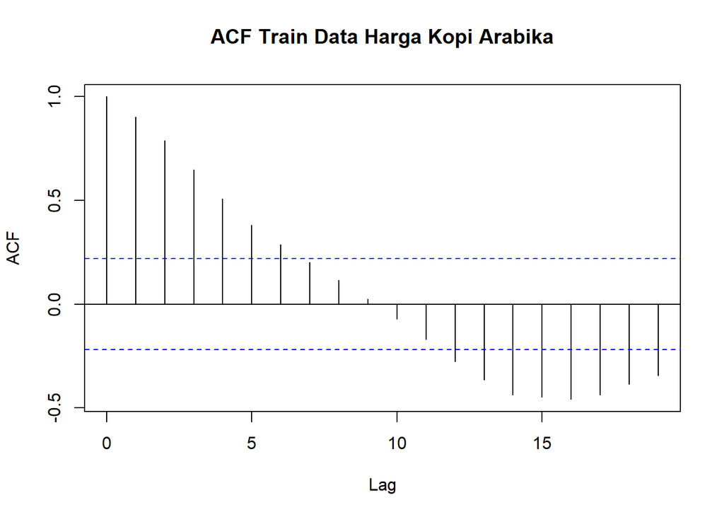

```r
acf(train_data, main = "ACF Train Data Harga Kopi Arabika")
```

Dari plot di atas menunjukkan bahwa data tidak stasioner karena nilai ACF menurun secara perlahan.

### Uji ADF Train Data

```r
adf.test(train_data)
```

```
##
##  Augmented Dickey-Fuller Test
##
## data:  train_data
## Dickey-Fuller = -2.6673, Lag order = 4, p-value = 0.3027
## alternative hypothesis: stationary
```

$H_0$ : Data tidak stasioner dalam rataan $H_1$ : Data stasioner dalam rataan

Karena p-value > 0.05, maka gagal menolak H0 yang artinya terdapat ketidakstasioneran pada data.

### Box-Cox Train Data

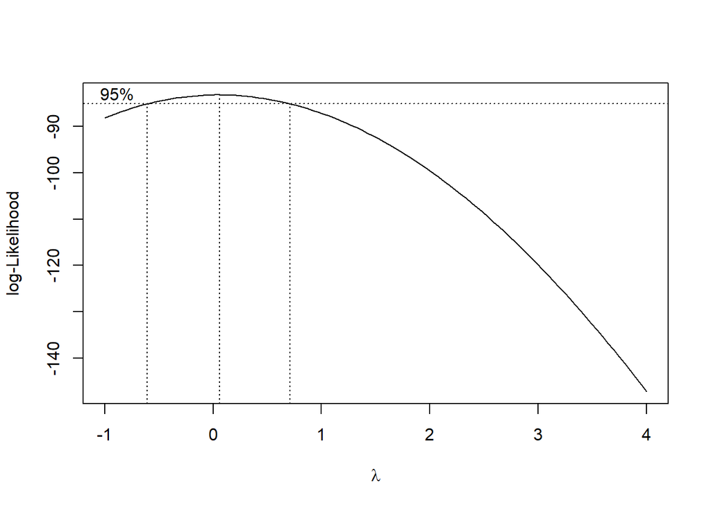

```r
idx = seq(401:480)
bx = boxcox(train_data~idx, lambda = seq(-1,4,by=1))
```

```r
#Nilai Rounded Lambda
lambda = bx$x[which.max(bx$y)]
lambda
```

```
## [1] 0.06060606
```

```r
#SK
bx$x[bx$y > max(bx$y) - 1/2 * qchisq(.95,1)]
```

```
##  [1] -0.59595960 -0.54545455 -0.49494949 -0.44444444 -0.39393939 -0.34343434
##  [7] -0.29292929 -0.24242424 -0.19191919 -0.14141414 -0.09090909 -0.04040404
## [13]  0.01010101  0.06060606  0.11111111  0.16161616  0.21212121  0.26262626
## [19]  0.31313131  0.36363636  0.41414141  0.46464646  0.51515152  0.56565657
## [25]  0.61616162  0.66666667
```

Plot di atas menunjukkan nilai *rounded value* ($\lambda$) optimum sebesar **0.06** dan pada selang kepercayaan 95% nilai memiliki batas bawah **-0.59** dan batas atas **0.66**. Selang tersebut tidak memuat nilai satu sehingga dapat dikatakan bahwa data tidak stasioner dalam ragam.

### Test Data

```r
test_data = ts_koi[(train_size + 1):length(ts_koi)]
print(test_data)
```

```
##  [1] 2.4496 2.2805 2.2207 2.0858 2.0756 1.9057 1.9257 1.6958 1.6707 1.6901
## [11] 1.5772 1.4586 1.4546 1.4813 1.4661 1.4579 1.5260 1.4088 1.2946 1.3166
```

```r
mean(test_data)
```

```
## [1] 1.722095
```

```r
var(test_data)
```

```
## [1] 0.1192386
```

### Plot Time Series Test Data

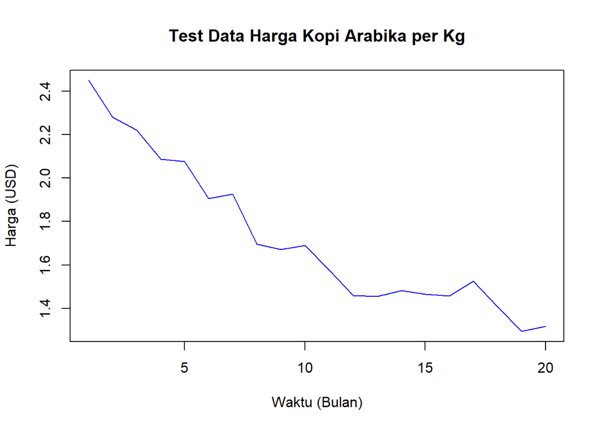

```r
ts.plot(test_data, main = "Test Data Harga Kopi Arabika per Kg", ylab = "Harga (USD)", xlab = "Waktu (Bulan)", col = "blue")
```

### ACF Test Data

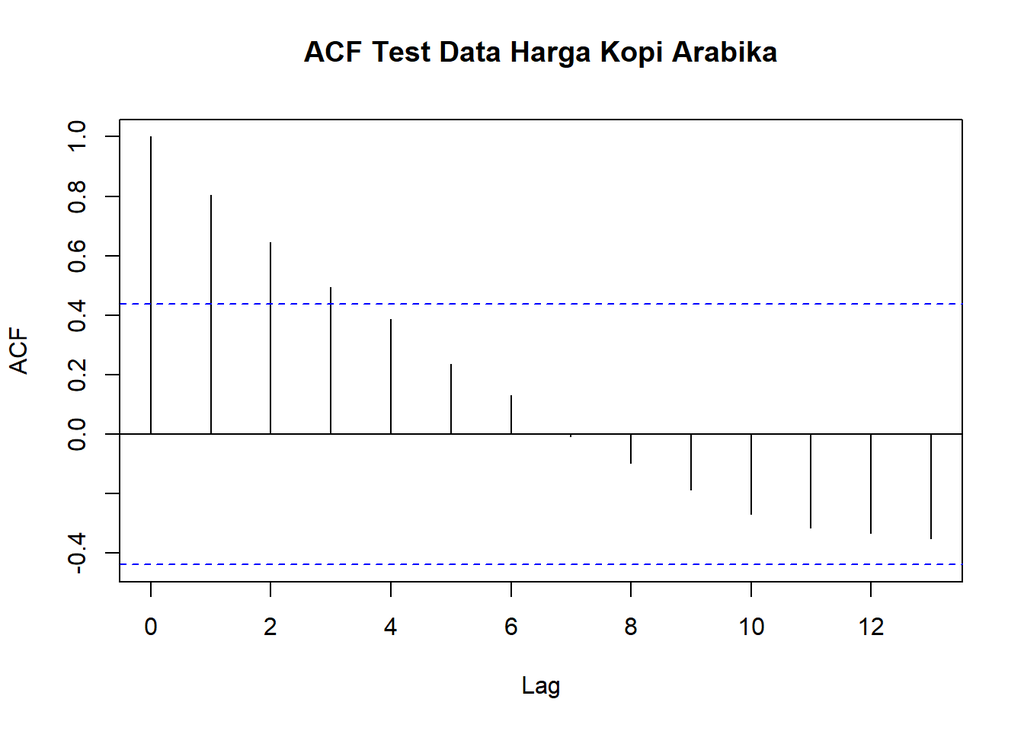

```r
acf(test_data, main = "ACF Test Data Harga Kopi Arabika")
```

Dari plot di atas menunjukkan bahwa data tidak stasioner karena nilai ACF menurun secara perlahan.

### Uji ADF Test Data

```r
adf.test(test_data)
```

```
##
##  Augmented Dickey-Fuller Test
##
## data:  test_data
## Dickey-Fuller = -1.4907, Lag order = 2, p-value = 0.7664
## alternative hypothesis: stationary
```

$H_0$ : Data tidak stasioner dalam rataan $H_1$ : Data stasioner dalam rataan

Karena p-value > 0.05, maka gagal menolak H0 yang artinya terdapat ketidakstasioneran pada data.

### Box-Cox Test Data

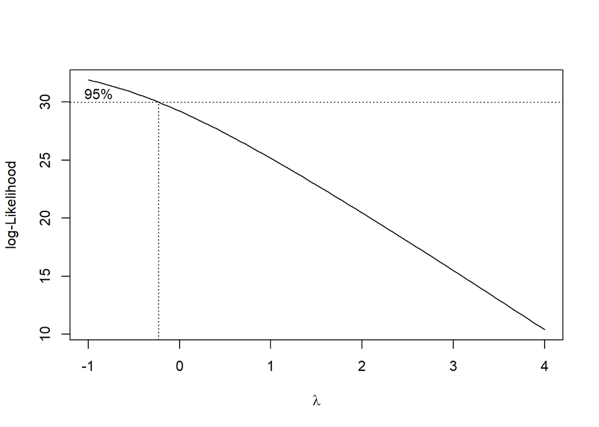

```r
idy = seq(481:500)
by = boxcox(test_data~idy, lambda = seq(-1,4,by=1))
```

```r
#Nilai Rounded Lambda
lambda = by$x[which.max(by$y)]
lambda
```

```
## [1] -1
```

```r
#SK
by$x[by$y > max(by$y) - 1/2 * qchisq(.95,1)]
```

```
##  [1] -1.0000000 -0.9494949 -0.8989899 -0.8484848 -0.7979798 -0.7474747
##  [7] -0.6969697 -0.6464646 -0.5959596 -0.5454545 -0.4949495 -0.4444444
## [13] -0.3939394 -0.3434343 -0.2929293 -0.2424242
```

Plot di atas menunjukkan nilai *rounded value* ($\lambda$) optimum sebesar **-1** dan pada selang kepercayaan 95% nilai memiliki batas bawah **-1** dan batas atas **-0.24**. Selang tersebut tidak memuat nilai satu sehingga dapat dikatakan bahwa data tidak stasioner dalam ragam.

## Penanganan

### Transformasi Box-Cox

```r
library(forecast)
```

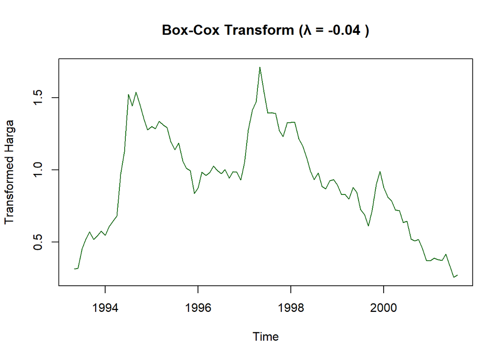

```r
lambda_opt = -0.04
ts_koi_bc = BoxCox(ts_koi, lambda = lambda_opt)

plot(ts_koi_bc, main = paste("Box-Cox Transform (λ =", round(lambda_opt, 2), ")"),
     ylab = "Transformed Harga", col = "darkgreen")
```

#### Plot Setelah Transformasi

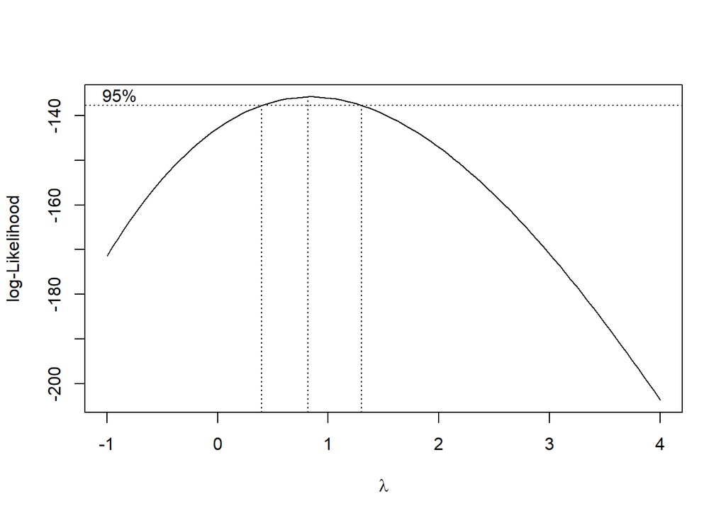

```r
## Plot Box-Cox setelah transformasi
b = boxcox(ts_koi_bc~index, lambda = seq(-1,4,by=1))
```

Karena nilai 1 sudah masuk dalam selang kepercayaan 95%, maka data sudah stasioner dalam ragam.

### Diferensiasi

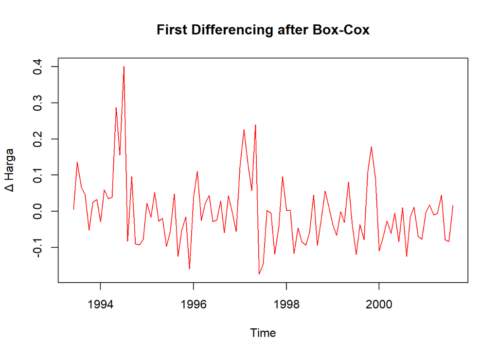

```r
ts_koi_diff1 = diff(ts_koi_bc, differences = 1)

plot(ts_koi_diff1, main = "First Differencing after Box-Cox",
     ylab = "Δ Harga", col = "red")
```

#### Plot ACF dan PACF Setelah Diferensiasi

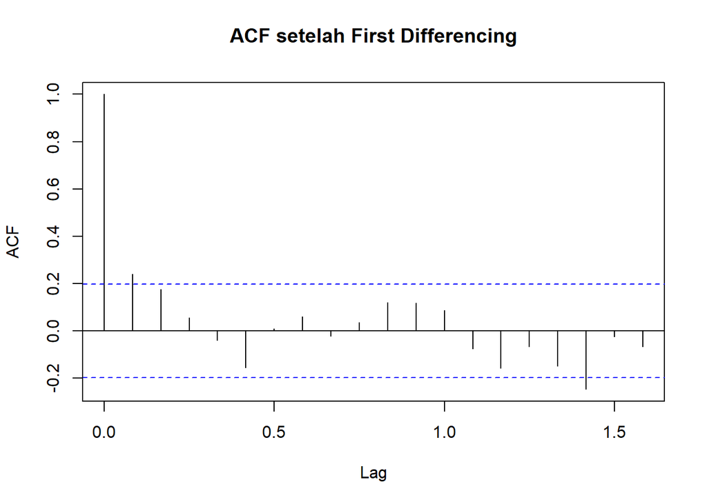

```r
# Cek ACF & ADF setelah differencing
acf(ts_koi_diff1, main = "ACF setelah First Differencing")
```

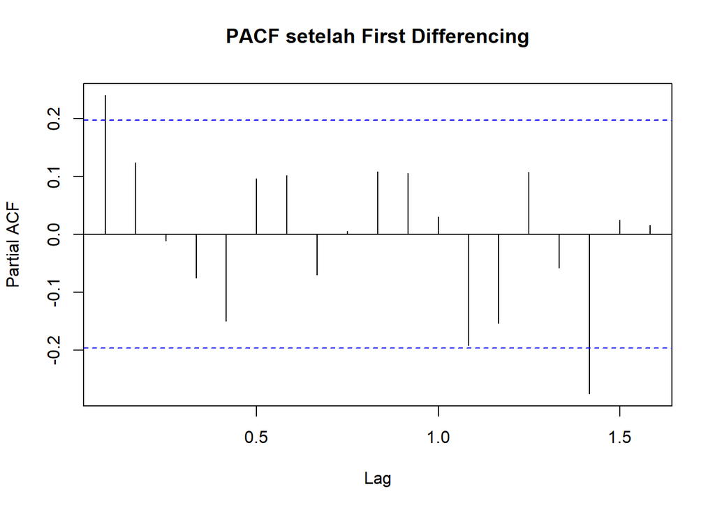

```r
pacf(ts_koi_diff1, main = "PACF setelah First Differencing")
```

#### Uji ADF Setelah Diferensiasi

```r
adf.test(ts_koi_diff1)
```

```
##
##  Augmented Dickey-Fuller Test
##
## data:  ts_koi_diff1
## Dickey-Fuller = -5.1528, Lag order = 4, p-value = 0.01
## alternative hypothesis: stationary
```

$H_0$ : Data tidak stasioner dalam rataan $H_1$ : Data stasioner dalam rataan Karena p-value < 0.05, maka tolak H0 yang artinya data sudah stasioner dalam rataan.

## Identifikasi Model

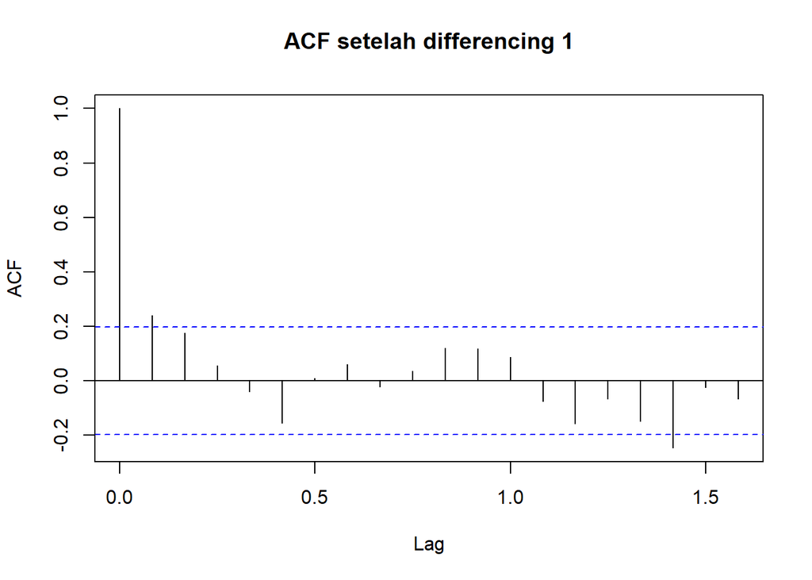

```r
acf(ts_koi_diff1, main = "ACF setelah differencing 1")
```

```r
pacf(ts_koi_diff1, main = "PACF setelah differencing 1")
library(TSA)
eacf(ts_koi_diff1)
```

```
## AR/MA
##   0 1 2 3 4 5 6 7 8 9 10 11 12 13
## 0 x o o o o o o o o o o  o  o  o
## 1 x o o o o o o o o o o  o  o  o
## 2 o x o o o o o o o o o  o  o  o
## 3 o o o o o o o o o o o  o  o  o
## 4 x o x x o o o o o o o  o  o  o
## 5 x x o x o o o o o o o  o  o  o
## 6 x x x o o o o o o o o  o  o  o
## 7 x o x x o o o o o o o  o  o  o
```

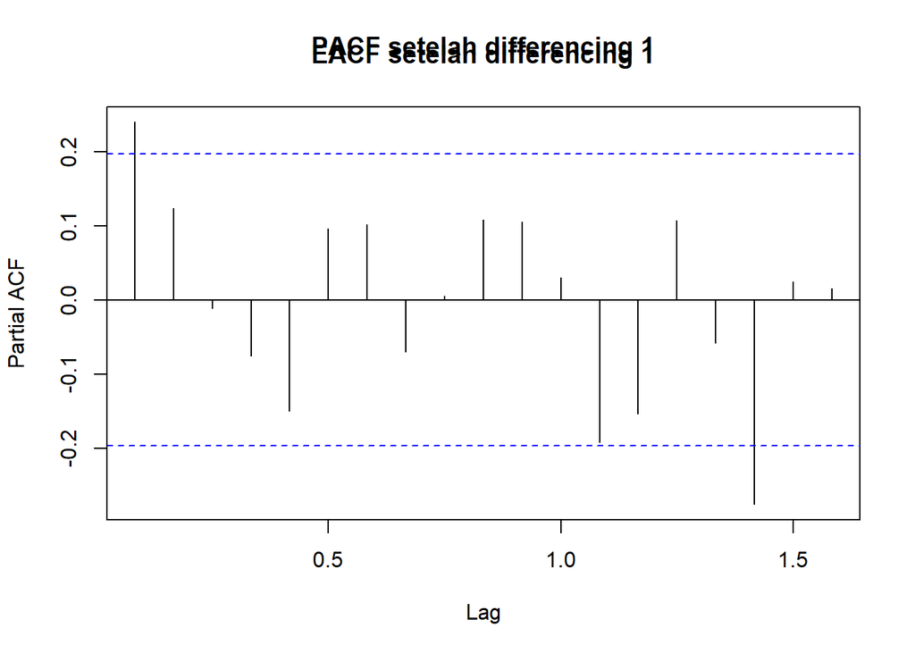

```r
title("EACF setelah differencing 1")
```

```r
fit_arima = Arima(ts_koi, order = c(0, 1, 1), lambda = lambda_opt)  # pakai lambda kalau ada BoxCox
summary(fit_arima)
```

```
## Series: ts_koi
## ARIMA(0,1,1)
## Box Cox transformation: lambda= -0.04
##
## Coefficients:
##          ma1
##       0.1878
## s.e.  0.0863
##
## sigma^2 = 0.008398:  log likelihood = 96.61
## AIC=-189.22   AICc=-189.09   BIC=-184.03
##
## Training set error measures:
##                        ME      RMSE       MAE        MPE    MAPE     MASE
## Training set -0.003461041 0.3403995 0.2112203 -0.4705476 6.83223 0.189736
##                    ACF1
## Training set -0.1135723
```

## Perbandingan Model

```r
library(forecast)

# Fit beberapa model ARIMA
fit1 <- Arima(ts_koi, order = c(0,1,1), lambda = lambda_opt)
fit2 <- Arima(ts_koi, order = c(1,1,1), lambda = lambda_opt)
fit3 <- Arima(ts_koi, order = c(2,1,2), lambda = lambda_opt)

# Buat fungsi untuk ambil metrik model
get_metrics <- function(fit) {
  err <- accuracy(fit)
  data.frame(
    Model = deparse(fit$call),
    AIC = AIC(fit),
    BIC = BIC(fit),
    RMSE = err["Training set","RMSE"],
    MAE = err["Training set","MAE"],
    MAPE = err["Training set","MAPE"]
  )
}

# Kumpulkan semua model
results <- rbind(
  get_metrics(fit1),
  get_metrics(fit2),
  get_metrics(fit3)
)

print(results)
```

```
##                                                        Model       AIC
## 1 Arima(y = ts_koi, order = c(0, 1, 1), lambda = lambda_opt) -189.2168
## 2 Arima(y = ts_koi, order = c(1, 1, 1), lambda = lambda_opt) -189.5505
## 3 Arima(y = ts_koi, order = c(2, 1, 2), lambda = lambda_opt) -194.2578
##         BIC      RMSE       MAE     MAPE
## 1 -184.0266 0.3403995 0.2112203 6.832230
## 2 -181.7651 0.3395303 0.2094449 6.805184
## 3 -181.2822 0.3040627 0.2006309 6.625047
```